# Критерий Манна-Кендалла

Olenev Roman

27.11.2023

Критерий Манна-Кендалла для проверки временного ряда на наличие монотонного тренда - статистический критерий, основанный на ранговом коэффициенте корреляции Кендалла.

Коэффициент корреляции Кендалла $\tau(\xi,\eta)$. Пусть даны независимые $(\xi_1,\eta_1)^T,(\xi_2,\eta_2)^T\sim (\xi,\eta)^T$. Тогда
$$\tau(\xi,\eta)=\rho(sign(\xi_2-\xi_1),sign(\eta_2-\eta_1))=P((\xi_2-\xi_1)(\eta_2-\eta_1)>0)-P((\xi_2-\xi_1)(\eta_2-\eta_1)<0).$$

Пусть дана выборка $(x_1,y_1),(x_2,y_2),...,(x_n,y_n)$, тогда
$$\hat\tau=\frac{n_c-n_d}{n_0},$$

где $\hat\tau$ - оценка коэффициента корреляции Кендалла, $n_c$ - количество одинаково упорядоченных пар, $n_d$ - количество по-разному упорядоченных пар, $n_0$ - количество комбинаций пар, то есть $n_0=C_n^2=n(n-1)/2$. Пара $(x_i,y_i),(x_j,y_j)$ считается одинаково упорядоченной, если $sign(x_i-x_j)=sign(y_i-y_j)$, в противном случае пара считается по-разному упорядоченной.

Для проверки временного ряда на наличие монотонного тренда используют критерий оценки значимости коэффициента корреляции Кендалла.

Пусть $\xi$ - номера точек, $\eta$ - значения временного ряда. Тогда $H_0: \tau=0$, если $H_0$ отвергается, то у временного ряда есть монотонный тренд.

При верной нулевой гипотезе распределение $\hat\tau$ аппроксимируется нормальным распределением $N(0,\frac{2(2n+5)}{9n(n-1)})$. Для проверки гипотезы используется статистика $z=\frac{\tau}{\sqrt{D_\tau}}=\frac{n_c-n_d}{\sqrt{n(n-1)(2n+5)/18}}$, которая сходится по распределению к стандартному нормальному распределению при $n\xrightarrow{}\infty$.

## Численное моделирование, ошибка первого рода

Исследуем ошибку первого рода, рассмотрев распределение p-values для ряда, удовлетворяющего нулевой гипотезе: $f(t)=0+N(0,1),\ t=\overline{1,200}$. Будем 10000 раз генерировать временной ряд длины 200 и находить для него p-value. На графиках представлены пример временного ряда и распределение p-values.

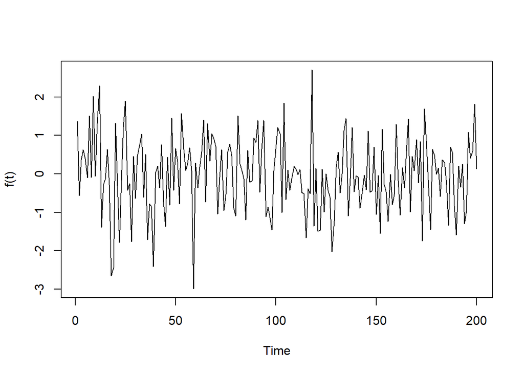

```r
set.seed(42)
plot(ts(rnorm(200)),ylab="f(t)")
```

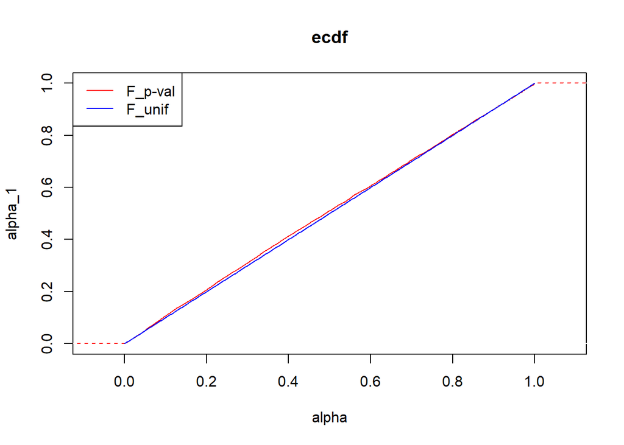

```r
temp <- c(1:10000)
for (i in c(1:10000)){
  temp[i] <- MannKendall(ts(rnorm(200)))$sl
}
plot(ecdf(temp),verticals=TRUE,do.points=FALSE,col.01line=FALSE,ylab="alpha_1",
     xlab="alpha",col="red",main="ecdf")
x <- seq(0, 1, .005)
prob <- punif(x,0,1)
lines(x, prob,col="blue")
legend("topleft",legend = c("F_p-val", "F_unif"), col = c("red","blue"),lwd=1)
```

Получили распределение, соответствующее точному критерию.

Исследуем ошибку первого рода, рассмотрев распределение p-values для ряда, удовлетворяющего нулевой гипотезе и соответствующего функции:$f(x)=4sin(x)+N(0,1)$. 200 значений временного ряда $f(x)$ вычисляются для 200 значений $x$ (с одинаковым шагом) из промежутка $[0+i/10,end\cdot5+i/10]$, где $end\sim U(1,2),\ i=\overline{1,10000}$.

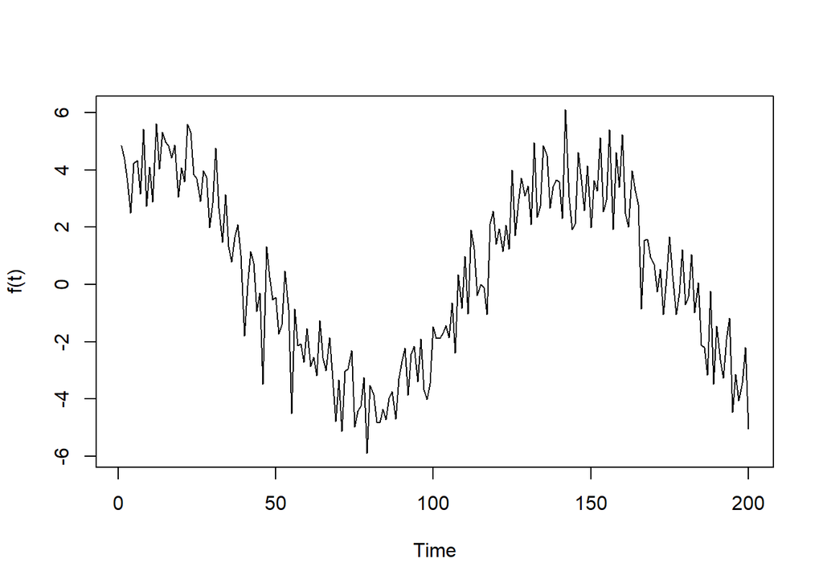

```r
set.seed(42)
end = runif(1,1,2)
sq = seq(0+i/10,end*5+i/10,length.out=200)
plot(ts(4*sin(sq)+rnorm(length(sq))),ylab="f(t)")
```

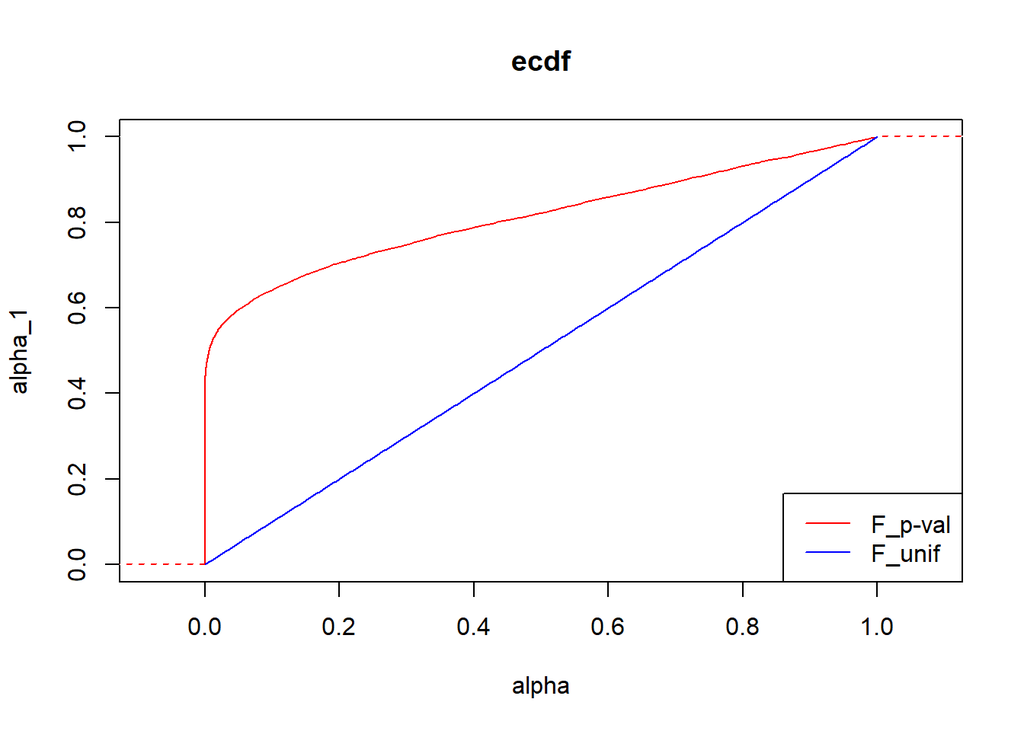

```r
temp2 <- c(1:10000)
for (i in c(1:10000)){
  end = runif(1,1,2)
  sq = seq(0+i/10,end*5+i/10,length.out=200)
  temp2[i] <- MannKendall(ts(4*sin(sq)+rnorm(length(sq))))$sl
}
plot(ecdf(temp2),verticals=TRUE,do.points=FALSE,col.01line=FALSE,
     ylab="alpha_1", xlab="alpha",col="red",main="ecdf")
x <- seq(0, 1, .005)
prob <- punif(x,0,1)
lines(x, prob,col="blue")
legend("bottomright",legend = c("F_p-val", "F_unif"), col = c("red","blue"),lwd=1)
```

Получили распределение, соответствующее радикальному критерию.

Посмотрим, что будет, если 200 значений временного ряда $f(x)$ вычисляются для 200 значений $x$ (с одинаковым шагом) из промежутка $[0+i/10,end\cdot50+i/10]$, где $end\sim U(1,2),\ i=\overline{1,10000}$. (то есть временной ряд, подающийся на вход, содержит в себе сильно больше полных периодов сезонности)

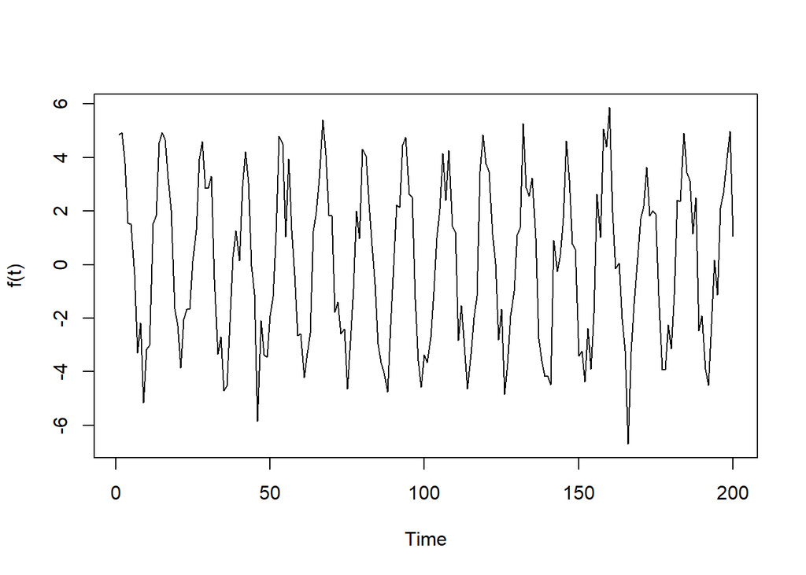

```r
set.seed(42)
end = runif(1,1,2)
sq = seq(0+i/10,end*50+i/10,length.out=200)
plot(ts(4*sin(sq)+rnorm(length(sq))),ylab="f(t)")
```

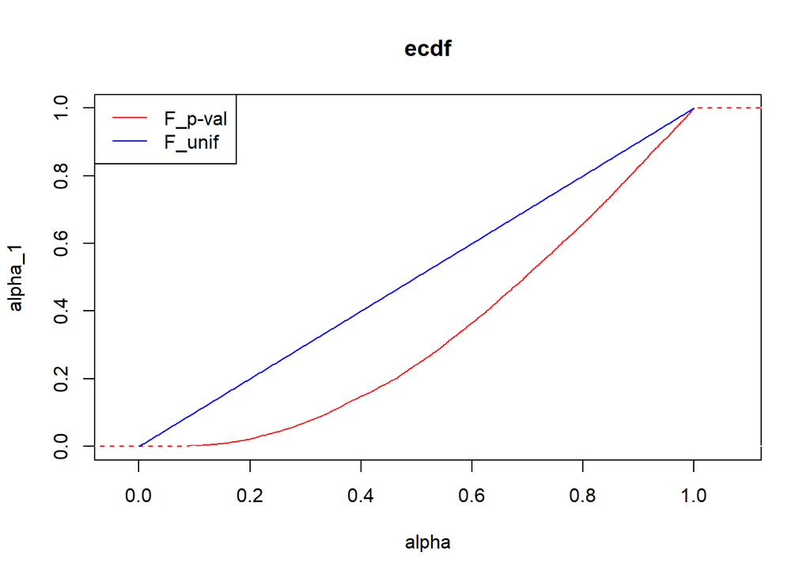

```r
temp3 <- c(1:10000)
for (i in c(1:10000)){
  end = runif(1,1,2)
  sq = seq(0+i/10,end*50+i/10,length.out=200)
  temp3[i] <- MannKendall(ts(4*sin(sq)+rnorm(length(sq))))$sl
}
plot(ecdf(temp3),verticals=TRUE,do.points=FALSE,col.01line=FALSE,
     ylab="alpha_1", xlab="alpha",col="red",main="ecdf")
x <- seq(0, 1, .005)
prob <- punif(x,0,1)
lines(x, prob,col="blue")
legend("topleft",legend = c("F_p-val", "F_unif"), col = c("red","blue"),lwd=1)
```

Получили распределение, соответствующее консервативному критерию.

Исследуем ошибку первого рода, рассмотрев распределение p-values для ряда, удовлетворяющего нулевой гипотезе и соответствующего функции:$f(x)=4sin(x)+N(0,1)$. 200 значений временного ряда $f(x)$ вычисляются для 200 значений $x$ (с одинаковым шагом) из промежутка $[0,end\cdot\pi+\pi]$, где $end$ равновероятно принмает значения $\{2,4,6,8,10\}$. (равное число промежутков возрастания и убывания)

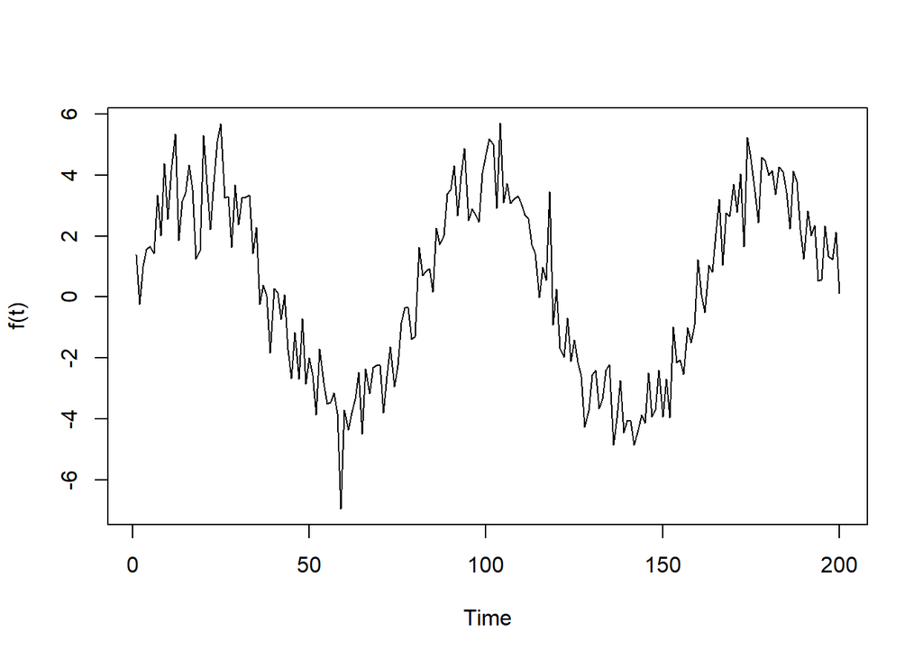

```r
set.seed(42)
sq = seq(0,4*pi+pi,length.out=200)
plot(ts(4*sin(sq)+rnorm(length(sq))),ylab="f(t)")
```

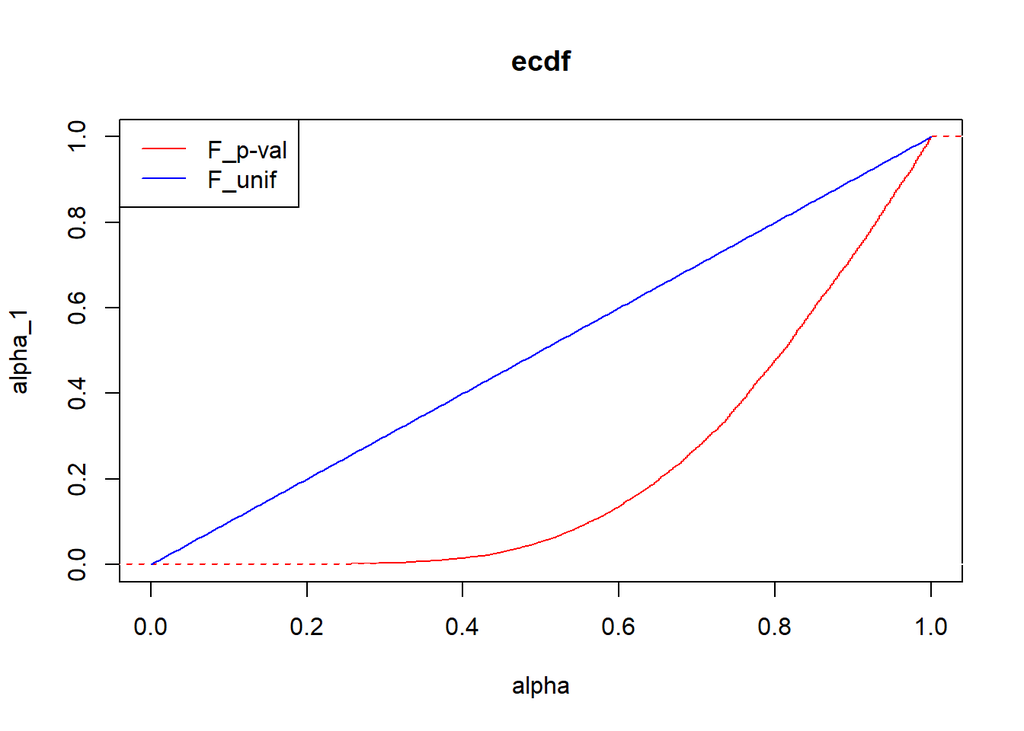

```r
temp4 <- c(1:10000)
for (i in c(1:10000)){
  end = sample.int(5,1)*2
  sq = seq(0,end*pi+pi,length.out=200)
  temp4[i] <- MannKendall(ts(4*sin(sq)+rnorm(length(sq))))$sl
}
plot(ecdf(temp4),xlim=c(0,1),ylim=c(0,1),verticals=TRUE,do.points=FALSE,
     col.01line=FALSE,ylab="alpha_1", xlab="alpha",col="red",
     main="ecdf")
x <- seq(0, 1, .005)
prob <- punif(x,0,1)
lines(x, prob, col="blue")
legend("topleft",legend = c("F_p-val", "F_unif"), col = c("red","blue"),lwd=1)
```

Получили распределение, соответствующее консервативному критерию.

Таким образом, критерием можно пользоваться, если у временного ряда отсутствует сезонность. Можно пытаться использовать критерий для ряда с сезонностью, если число полных периодов сезонности, входящих во временной ряд, достаточно большое (относительно длины ряда), а также если временной ряд состоит из равного числа промежутков возрастания и убывания.

## Численное моделирование, мощность

Исследуем мощность критерия, рассмотрев распределение p-values для ряда, удовлетворяющего альтернативной гипотезе и соответствующего функции:$f(x)=x+N(0,1)$. 200 значений временного ряда $f(x)$ вычисляются для 200 значений $x$ (с одинаковым шагом) из промежутка $[0,10]$.

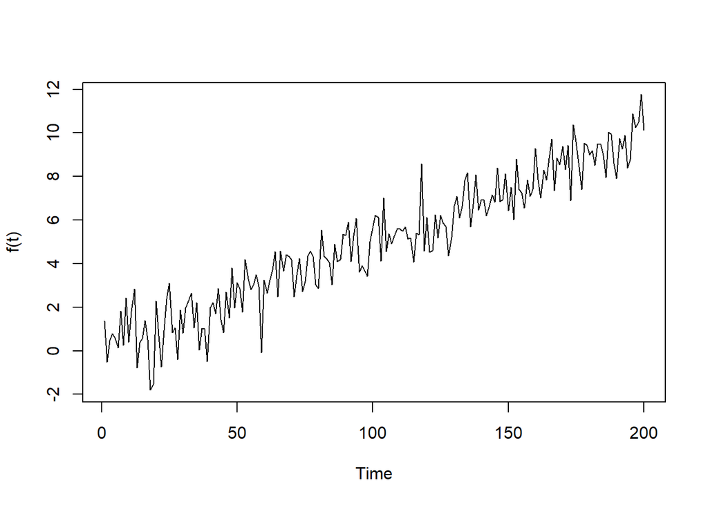

```r
set.seed(42)
plot(ts(seq(0,10,length.out=200)+rnorm(200)),ylab="f(t)")
```

```r
temp5 <- c(1:10000)
for (i in c(1:10000)){
  sq <- seq(0,10,length.out=200)
  temp5[i] <- MannKendall(ts(sq+rnorm(length(sq))))$sl
}
plot(ecdf(temp5),xlim=c(0,1),ylim=c(0,1),verticals=TRUE,do.points=FALSE,
     col.01line=FALSE,
     col="red",ylab="betta",xlab="alpha",
     main="ecdf_p-val")
```

[output not shown]

Мощность критерия против данной альтернативы (линейный тренд) равна 1.

Исследуем мощность критерия, рассмотрев распределение p-values для ряда, удовлетворяющего альтернативной гипотезе и соответствующего функции:$f(x)=x^3+N(0,1)$. 200 значений временного ряда $f(x)$ вычисляются для 200 значений $x$ (с одинаковым шагом) из промежутка $[0,2]$.

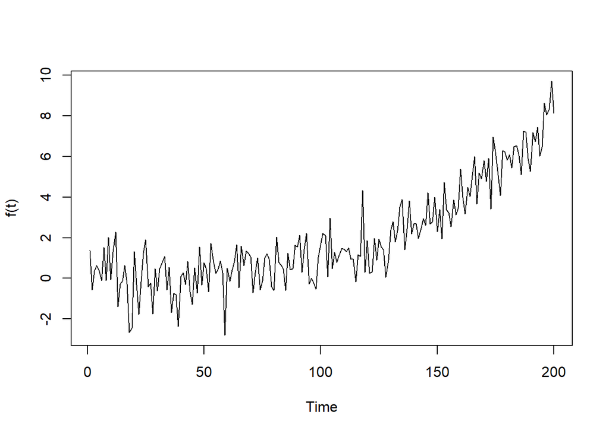

```r
set.seed(42)
plot(ts((seq(0,2,length.out=200))^3+rnorm(200)),ylab="f(t)")
```

```r
temp10 <- c(1:10000)
for (i in c(1:10000)){
  sq <- seq(0,2,length.out=200)
  temp10[i] <- MannKendall(ts((sq)^3+rnorm(length(sq))))$sl
}
plot(ecdf(temp10),xlim=c(0,1),ylim=c(0,1),verticals=TRUE,do.points=FALSE,
     col.01line=FALSE,
     col="red",ylab="betta", xlab="alpha",
     main="ecdf_p-val")
```

[output not shown]

Мощность критерия против данной альтернативы (кубический тренд) равна 1.

Исследуем мощность критерия, рассмотрев распределение p-values для ряда, удовлетворяющего альтернативной гипотезе и соответствующего функции:$f(x)=x+sin(5x)+N(0,1)$. 200 значений временного ряда $f(x)$ вычисляются для 200 значений $x$ (с одинаковым шагом) из промежутка $[0,10]$.

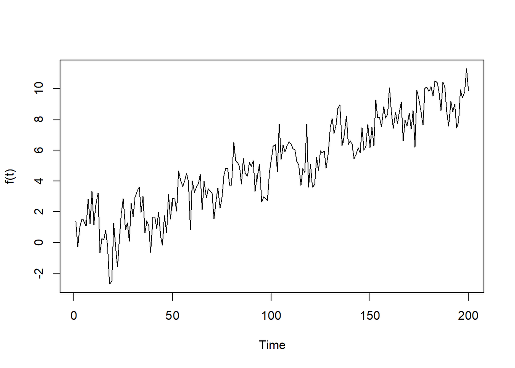

```r
set.seed(42)
plot(ts(seq(0,10,length.out=200)+rnorm(200)+sin(seq(0,10,length.out=200)*5)),
     ylab="f(t)")
```

```r
temp6 <- c(1:10000)
for (i in c(1:10000)){
  sq <- seq(0,10,length.out=200)
  temp6[i] <- MannKendall(ts(sq+rnorm(length(sq))+sin(sq*5)))$sl
}
plot(ecdf(temp6),xlim=c(0,1),ylim=c(0,1),verticals=TRUE,do.points=FALSE,
     col.01line=FALSE,
     col="red",ylab="betta", xlab="alpha",
     main="ecdf_p-val")
```

[output not shown]

Мощность критерия против данной альтернативы (линейный тренд + сезонность) равна 1.

Исследуем мощность критерия, рассмотрев распределение p-values для ряда, удовлетворяющего альтернативной гипотезе и соответствующего функции:$f(x)=x+30sin(5x)+N(0,1)$ (предыдущий временной ряд с увеличенной амплитудой сезонных колебаний). 200 значений временного ряда $f(x)$ вычисляются для 200 значений $x$ (с одинаковым шагом) из промежутка $[0,10]$. Сравним с предыдущей альтернативой.

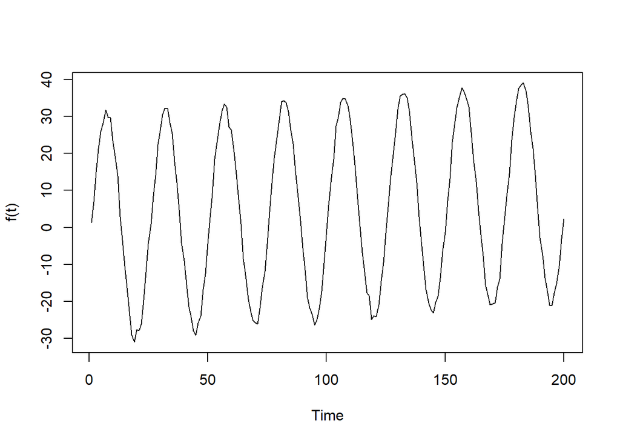

```r
set.seed(42)
plot(ts(seq(0,10,length.out=200)+rnorm(200)+30*sin(seq(0,10,length.out=200)*5)),
     ylab="f(t)")
```

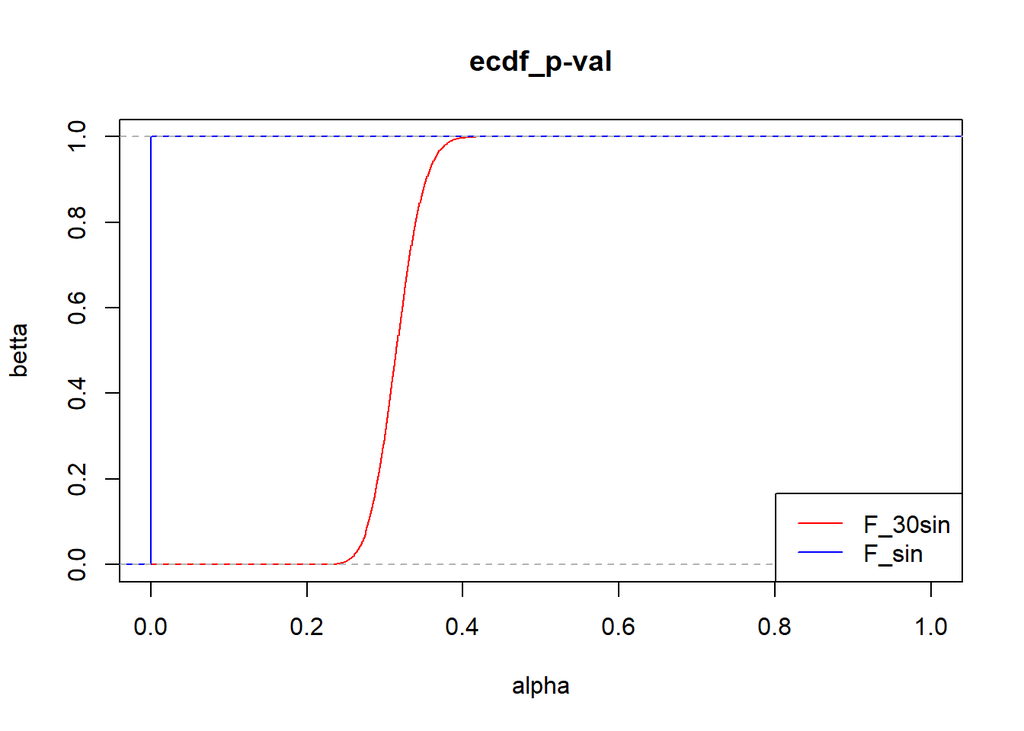

```r
temp7 <- c(1:10000)
for (i in c(1:10000)){
  sq <- seq(0,10,length.out=200)
  temp7[i] <- MannKendall(ts(sq+rnorm(length(sq))+30*sin(sq*5)))$sl
}
plot(ecdf(temp7),xlim=c(0,1),ylim=c(0,1),verticals=TRUE,do.points=FALSE,
     col.01line=FALSE,col="red",ylab="betta", xlab="alpha",
     main="ecdf_p-val")
lines(ecdf(temp6),verticals=TRUE,do.points=FALSE,
      col="blue",xlim=c(0,1),ylim=c(0,1))
legend("bottomright",legend = c("F_30sin", "F_sin"),
       col = c("red","blue"),lwd=1)
```

Видно, что при увеличении амплитуды сезонных колебаний мощность уменьшилась. Мощность также увеличится при выполнении условий предыдущего пункта для ошибки первого рода (мощность вырастет при увеличении числа колебаний относительно длины ряда).

Рассмотрим в качестве альтернативы ряд с немонотонным трендом. Пусть
$$f_1(t)=
\begin{cases}
\frac{1}{50}(t-99)^2+N(0,100),\ t\leqslant99
\\
t-99+N(0,100),\ else.
\end{cases},\ t=\overline{0,199}$$

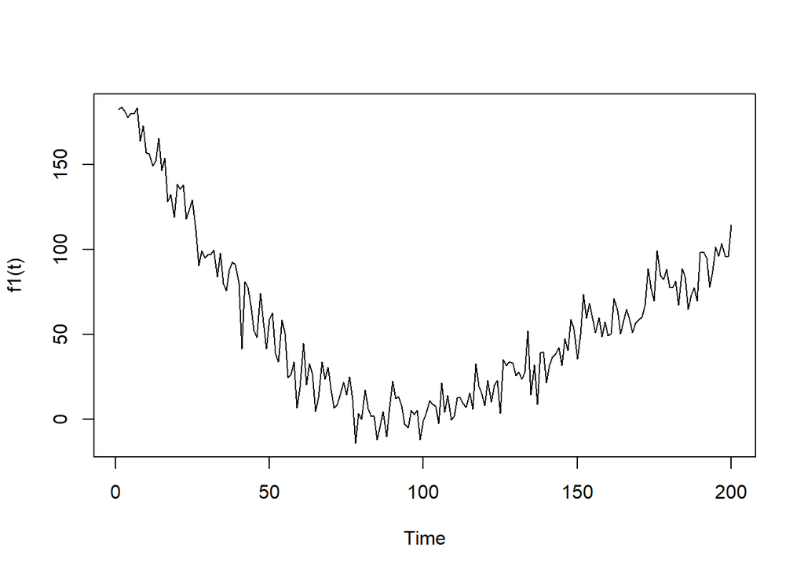

```r
x1 <- c(-99:0)
x2 <- c(1:100)
plot(ts(c((x1^2)/50, x2)+rnorm(200,0,10)),ylab="f1(t)")
```

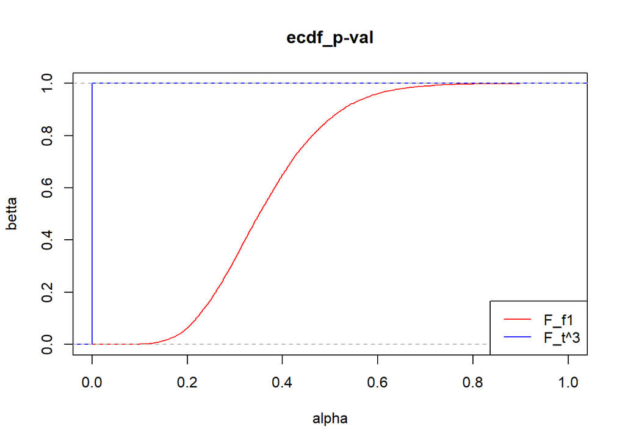

```r
temp8 <- c(1:10000)
for (i in c(1:10000)){
  temp8[i] <- MannKendall(ts(c((x1^2)/50, x2)+rnorm(200,0,10)))$sl
}
plot(ecdf(temp8),xlim=c(0,1),ylim=c(0,1),verticals=TRUE,do.points=FALSE,
     col.01line=FALSE,col="red",ylab="betta", xlab="alpha",
     main="ecdf_p-val")
lines(ecdf(temp10),verticals=TRUE,do.points=FALSE,
      col="blue",xlim=c(0,1),ylim=c(0,1))
legend("bottomright",legend = c("F_f1", "F_t^3"), col = c("red","blue"),lwd=1)
```

Видно, что критерий имеет низкую мощность против ряда с немонотонным трендом.

Таким образом, удалось убедиться, что данный критерий должен использоваться для выявления монотонного тренда, так как критерий является мощным против такой альтернативы. Критерий можно пытаться использовать для временных рядов с сезонностью, однако он может оказаться маломощным или радикальным. Существуют вариации критерия (Seasonal Mann-Kendall) для работы с такими временными рядами.